# Homework 6

Anna Schmidt

2/23/2022

#### **Parts 1 and 2**

**Open libraries**

```r
library(ggplot2) # for graphics
library(MASS) # for maximum likelihood estimation
```

**Read in data vector**

To illustrate, we will generate some fake data here:

(commented out since I replaced with my own data - see below)

```r
# # quick and dirty, a truncated normal distribution to work on the solution set
#
# z <- rnorm(n=3000,mean=0.2)
# z <- data.frame(1:3000,z)
# names(z) <- list("ID","myVar")
# z <- z[z$myVar>0,] # only include positive values of myVar
# str(z)
# summary(z$myVar)
```

In the third step of this exercise, you will substitute in your own data for this fake data set. But for now, use the code chunks below to see how you fit different statistical distributions to a vector of observations, and then estimate the maximum likelihood parameters for each distribution.

**Loading in my own data**

The data I am loading in here is length data (in mm) for zooplankton individuals that we collected at the CEREEP-Ecotron Ile-de-France “PLANAQUA” facility in Saint-Pierre-lès-Nemours, France. The .csv file I am loading in contains length data for zooplankton collected from the epilimnion (surface waters) of Lake 1 at night on August 1st, 2019.

```r
z <- read.table("HW6_M1_01AUG2019_N_EP_022_copy.csv", header=TRUE, sep=",")
z <- data.frame(z$length_mm) # only keep the length_mm column
z <- data.frame(1:223,z)
names(z) <- list("ID","myVar")
str(z)
```

```
## 'data.frame':    223 obs. of  2 variables:
##  $ ID   : int  1 2 3 4 5 6 7 8 9 10 ...
##  $ myVar: num  0.614 0.606 0.494 0.482 0.475 ...
```

```r
summary(z) # summary of min, Q1, median, mean, Q3, and max for myVar
```

```
##        ID            myVar
##  Min.   :  1.0   Min.   :0.1081
##  1st Qu.: 56.5   1st Qu.:0.2447
##  Median :112.0   Median :0.3029
##  Mean   :112.0   Mean   :0.3076
##  3rd Qu.:167.5   3rd Qu.:0.3664
##  Max.   :223.0   Max.   :0.6143
```

**Plot histogram of data**

Plot a histogram of the data, using a modification of the code from lecture. Here we are switching from `qplot` to `ggplot` for more graphics options. We are also rescaling the y axis of the histogram from counts to density, so that the area under the histogram equals 1.0.

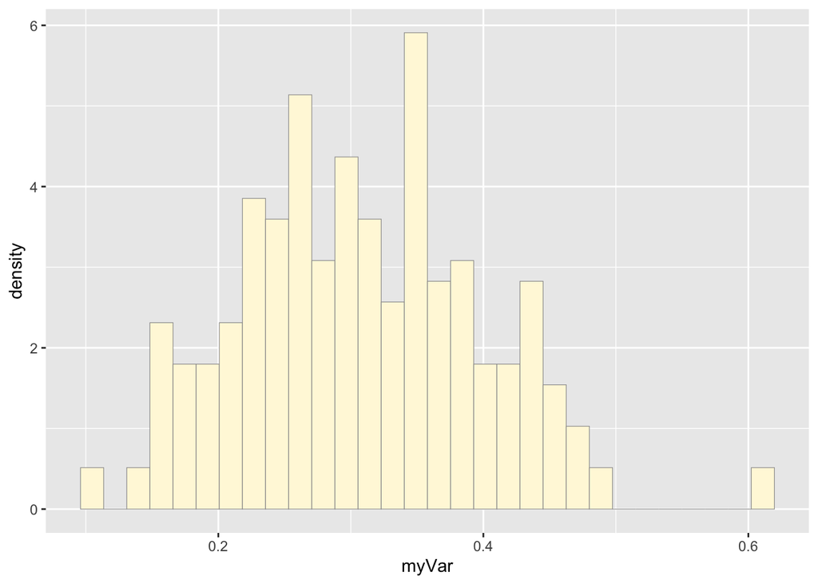

```r
p1 <- ggplot(data=z, aes(x=myVar, y=..density..)) +
  geom_histogram(color="grey60",fill="cornsilk",size=0.2)
print(p1)
```

**Add empirical density curve**

Now modify the code to add in a kernel density plot of the data. This is an empirical curve that is fitted to the data. It does not assume any particular probability distribution, but it smooths out the shape of the histogram:

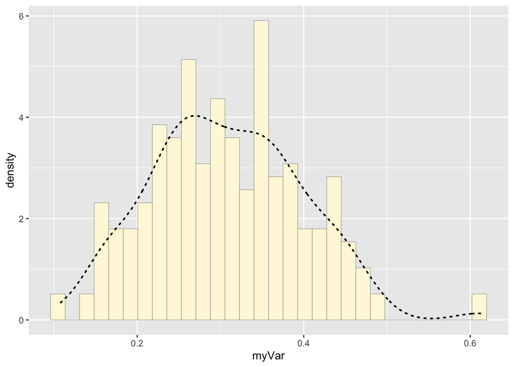

```r
p1 <-  p1 +  geom_density(linetype="dotted",size=0.75)
print(p1) # dashed line is the empirical curve
```

**Get maximum likelihood parameters for `normal`**

Next, fit a normal distribution to your data and grab the maximum likelihood estimators of the two parameters of the normal, the mean and the variance:

```r
normPars <- fitdistr(z$myVar,"normal")
print(normPars)
```

```
##       mean           sd
##   0.307611659   0.089921338
##  (0.006021578) (0.004257899)
```

```r
str(normPars)
```

```
## List of 5
##  $ estimate: Named num [1:2] 0.3076 0.0899
##   ..- attr(*, "names")= chr [1:2] "mean" "sd"
##  $ sd      : Named num [1:2] 0.00602 0.00426
##   ..- attr(*, "names")= chr [1:2] "mean" "sd"
##  $ vcov    : num [1:2, 1:2] 3.63e-05 0.00 0.00 1.81e-05
##   ..- attr(*, "dimnames")=List of 2
##   .. ..$ : chr [1:2] "mean" "sd"
##   .. ..$ : chr [1:2] "mean" "sd"
##  $ n       : int 223
##  $ loglik  : num 221
##  - attr(*, "class")= chr "fitdistr"
```

```r
normPars$estimate["mean"] # note structure of getting a named attribute
```

```
##      mean
## 0.3076117
```

**Plot `normal` probability density**

Now let’s call the `dnorm` function inside ggplot’s `stat_function` to generate the probability density for the normal distribution. Read about `stat_function` in the help system to see how you can use this to add a smooth function to any ggplot. Note that we first get the maximum likelihood parameters for a normal distribution fitted to thse data by calling `fitdistr`. Then we pass those parameters (`meanML` and `sdML` to `stat_function`):

```r
meanML <- normPars$estimate["mean"]
sdML <- normPars$estimate["sd"]

xval <- seq(0,max(z$myVar),len=length(z$myVar))

 stat <- stat_function(aes(x = xval, y = ..y..), fun = dnorm, colour="red", n = length(z$myVar), args = list(mean = meanML, sd = sdML))
 p1 + stat # red line is normal distribution
```

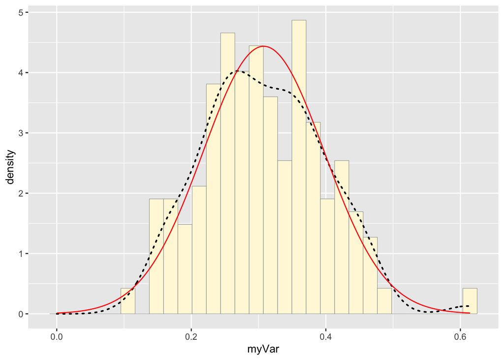

**Plot `exponential` probability density**

Now let’s use the same template and add in the curve for the exponential:

```r
expoPars <- fitdistr(z$myVar,"exponential")
rateML <- expoPars$estimate["rate"]

stat2 <- stat_function(aes(x = xval, y = ..y..), fun = dexp, colour="blue", n = length(z$myVar), args = list(rate=rateML))
 p1 + stat + stat2 # blue line is exponential distribution
```

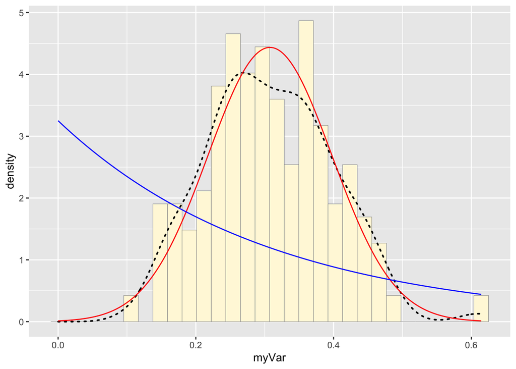

**Plot `uniform` probability density**

For the uniform, we don’t need to use `fitdistr` because the maximum likelihood estimators of the two parameters are just the minimum and the maximum of the data:

```r
stat3 <- stat_function(aes(x = xval, y = ..y..), fun = dunif, colour="darkgreen", n = length(z$myVar), args = list(min=min(z$myVar), max=max(z$myVar)))
 p1 + stat + stat2 + stat3 # green line is the uniform distribution
```

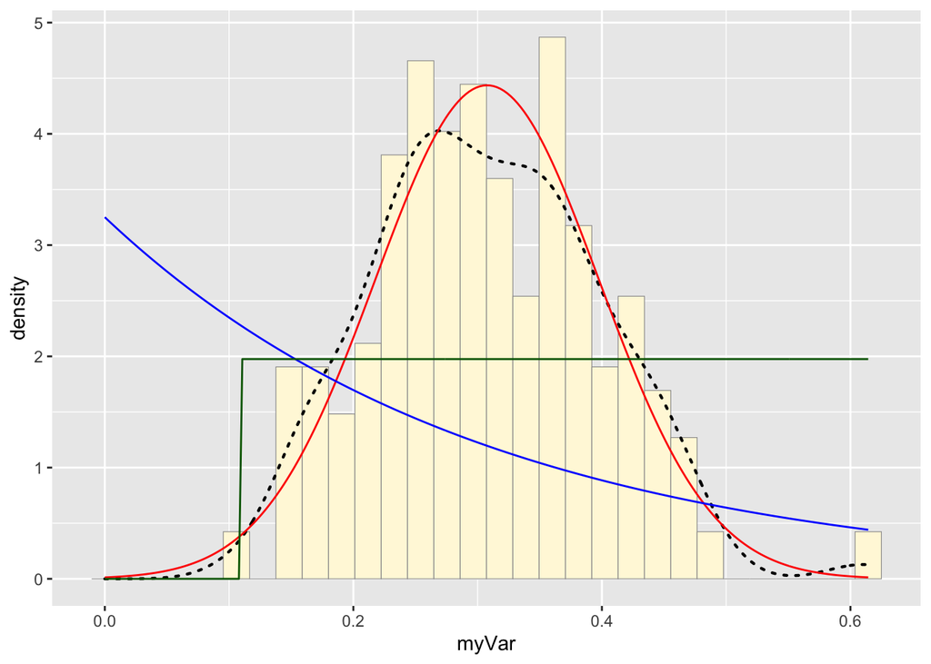

**Plot `gamma` probability density**

```r
gammaPars <- fitdistr(z$myVar,"gamma")
shapeML <- gammaPars$estimate["shape"]
rateML <- gammaPars$estimate["rate"]

stat4 <- stat_function(aes(x = xval, y = ..y..), fun = dgamma, colour="brown", n = length(z$myVar), args = list(shape=shapeML, rate=rateML))
 p1 + stat + stat2 + stat3 + stat4 # brown line is the gamma distribution
```

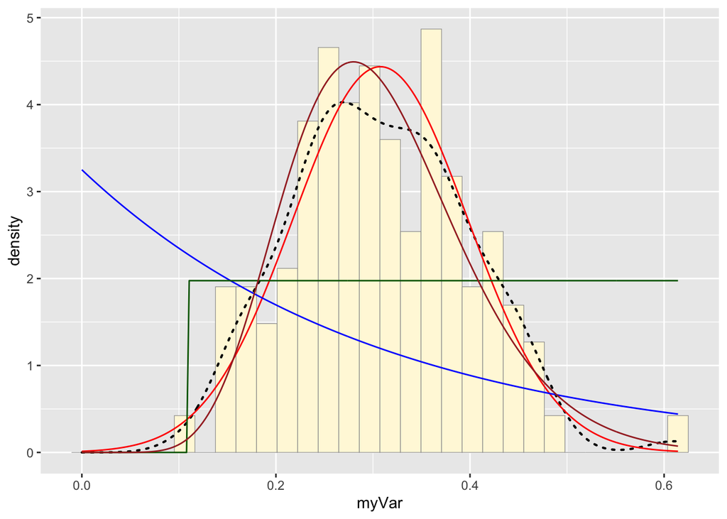

**Plot `beta` probability density**

This one has to be shown in its own plot because the raw data must be rescaled so they are between 0 and 1, and then they can be compared to the beta.

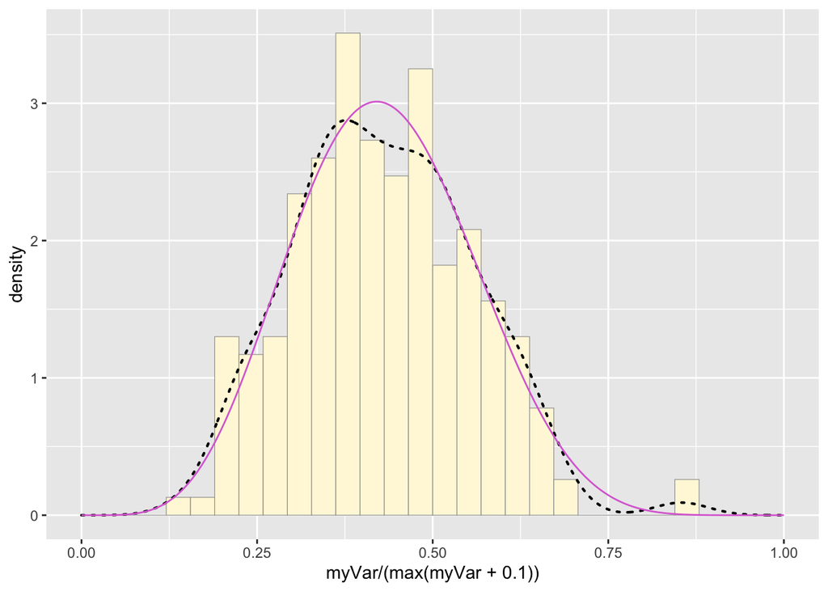

```r
pSpecial <- ggplot(data=z, aes(x=myVar/(max(myVar + 0.1)), y=..density..)) +
  geom_histogram(color="grey60",fill="cornsilk",size=0.2) +
  xlim(c(0,1)) +
  geom_density(size=0.75,linetype="dotted")

betaPars <- fitdistr(x=z$myVar/max(z$myVar + 0.1),start=list(shape1=1,shape2=2),"beta")
shape1ML <- betaPars$estimate["shape1"]
shape2ML <- betaPars$estimate["shape2"]

statSpecial <- stat_function(aes(x = xval, y = ..y..), fun = dbeta, colour="orchid", n = length(z$myVar), args = list(shape1=shape1ML,shape2=shape2ML))
pSpecial + statSpecial # purple line is the beta distribution
```

#### **Part 3**

The best-fitting distribution for my zooplankton length data is the **gamma distribution** (brown line above). This distribution follows the general trend of the length data and also slightly incorporates the outliers above 0.6 mm.

#### **Part 4**

**Getting the maximum likelihood parameters for the gamma distribution:**

```r
gammaPars <- fitdistr(z$myVar,"gamma")
shapeML <- gammaPars$estimate["shape"]
rateML <- gammaPars$estimate["rate"]
```

**Simulating a new data set with the same length as my original vector:**

```r
z_sim <- rgamma(n = 223, shape = shapeML, rate = rateML)
z_sim <- data.frame(1:223,z_sim)
names(z_sim) <- list("ID","myVar_sim")
str(z_sim)
```

```
## 'data.frame':    223 obs. of  2 variables:
##  $ ID       : int  1 2 3 4 5 6 7 8 9 10 ...
##  $ myVar_sim: num  0.329 0.298 0.306 0.246 0.485 ...
```

```r
summary(z_sim$myVar_sim)
```

```
##    Min. 1st Qu.  Median    Mean 3rd Qu.    Max.
##  0.1364  0.2458  0.2956  0.3068  0.3650  0.5674
```

**Plotting the new data set in a histogram with probability density curve:**

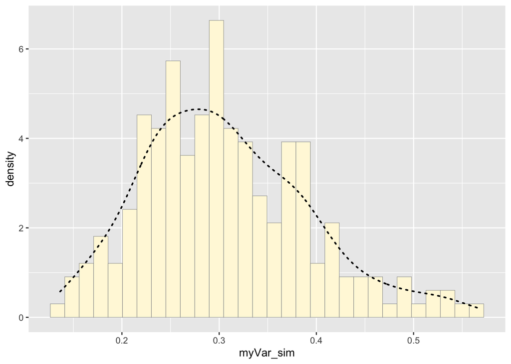

```r
p1 <- ggplot(data=z_sim, aes(x=myVar_sim, y=..density..)) +
  geom_histogram(color="grey60",fill="cornsilk",size=0.2) +
  geom_density(linetype="dotted",size=0.75)
print(p1) # dashed line is the empirical curve
```

**Fresh histogram of the original data with probability density curve:**

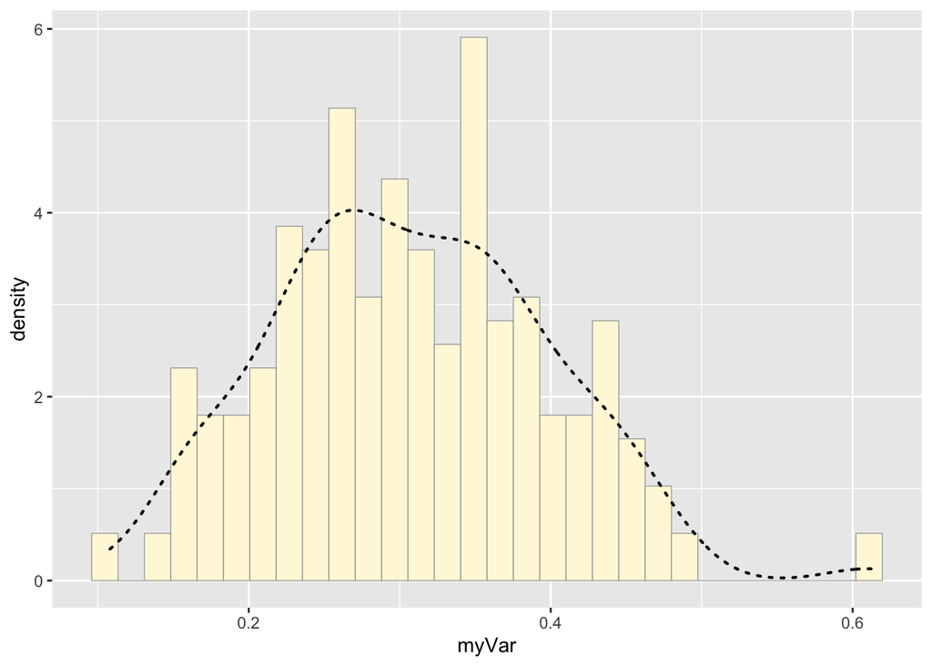

```r
p1 <- ggplot(data=z, aes(x=myVar, y=..density..)) +
  geom_histogram(color="grey60",fill="cornsilk",size=0.2) +
  geom_density(linetype="dotted",size=0.75)
print(p1) # dashed line is the empirical curve
```

Back to Home Page